# Tidy data et tidyverse: premiers pas dans la Data Science avec R

20 juillet 2018

## Pour commencer…. la *Data frame*?

## *Data frame* (1)

Regardez les éléments suivants: Que voyez-vous? Des prénoms, n'est-ce pas? De jolis prénoms!

[output not shown]

On peut choisir de visualiser ces prénoms de la façon suivante:

```
##      [,1]       [,2]         [,3]
## [1,] "Khadidja" "Fatima"     "Lucie"
## [2,] "Khalil"   "Fousseynou" "Lionel"
```

Quelle est la différence entre ces ensembles? Le premier est un vecteur, le second une matrice. Dans les deux cas, on a un ensemble homogène: des caractères (*string*).

## *Data frame* (2)

Maintenant regardons l'âge de ce beau monde:

```
## [1] 24 13 42 19 28 65
```

Comme avant, on peut réorganiser ces données aussi:

```
##      [,1] [,2] [,3]
## [1,]   24   13   42
## [2,]   19   28   65
```

On peut même, s'amuser à faire des calculs:

moyenne = 31.8333333

médiane = 26

## *Data frame* (3)

Maintenant, imaginez que vous voulez mettre côte-à-côte les prénoms et les ages:

```
##      nom          age
## [1,] "Khadidja"   "24"
## [2,] "Fatima"     "13"
## [3,] "Lucie"      "42"
## [4,] "Khalil"     "19"
## [5,] "Fousseynou" "28"
## [6,] "Lionel"     "65"
```

C'est mieux là, n'est-ce pas? Mais que remarque-t-on? Des *""* autour des chiffres. Retentons le calcul de l'âge moyen en prenant les données de ce tableau. On obtient: NA. *NA* designant *Non Available*, or l'on voit bien les chiffres. Toutefois, ils ne sont pas reconnus comme tels. C'est là qu'entre en scène la *Data frame*

## *Data frame* (4)

C'est un format de données rectangulaires (des colonnes et des lignes). C'est surtout un format qui permet de combiner des éléments de diverses natures. Regardons ça:

```
##          nom age
## 1   Khadidja  24
## 2     Fatima  13
## 3      Lucie  42
## 4     Khalil  19
## 5 Fousseynou  28
## 6     Lionel  65
```

On remarque là que les "" ont disparu. Les chiffres sont reconnus comme tels. Allons peu plus loin en ajoutant de nouvelles informations.

## *Data frame* (5)

Ajoutons de nouvelles informations:

```
##          nom age     sexe taille poids
## 1   Khadidja  24  féminin   1.75    62
## 2     Fatima  13  féminin   1.55    51
## 3      Lucie  42  féminin   1.72    79
## 4     Khalil  19 masculin   1.85    87
## 5 Fousseynou  28 masculin   1.73    60
## 6     Lionel  65 masculin   1.81    72
```

Là, nous voyons des données rectangulaires comme on en trouve souvent dans les enquêtes.

## *Data frame* (6)

Sans le savoir, nous avons crééé un format de données organisées (*tidy data*). Ces données respectent le principe de base du format *tidy*:

- chaque ligne est une observation;
- chaque colonne est un attribut.

Sans le savoir, toutefois, ce principe est souvent violé.

## *Data frame* (7)

Imaginez que ces personnes aient été observées il y a 5 ans, et que l'on souhaite reconduire les informations issues de cette observation:

```
##          nom age2018     sexe taille2018 taille2013 poids2018 poids2013
## 1   Khadidja      24  féminin       1.75       1.70        62        57
## 2     Fatima      13  féminin       1.55       1.20        51        41
## 3      Lucie      42  féminin       1.72       1.72        79        85
## 4     Khalil      19 masculin       1.85       1.40        87        57
## 5 Fousseynou      28 masculin       1.73       1.73        60        60
## 6     Lionel      65 masculin       1.81       1.81        72        71
```

Qu'est-ce qui ne va pas ici? Différentes colonnes font référence au même attribut:

- `taille2018` et `taille2013`: ça reste toujours la taille!
- `poids2018` et `poids2013`: ça reste toujours le poids!

## *Data frame* (8)

Que faire? Reorganiser les données.

```
##          nom annee age poids     sexe taille
## 1     Fatima  2013   8    41  féminin    1.2
## 2     Fatima  2018  13    51  féminin   1.55
## 3 Fousseynou  2013  23    60 masculin   1.73
## 4 Fousseynou  2018  28    60 masculin   1.73
## 5   Khadidja  2013  19    57  féminin    1.7
## 6   Khadidja  2018  24    62  féminin   1.75
```

Là, on retrouve le principe *tidy*. Maintenant, chaque ligne est une observation. Une observation qui n'est pas forcément la même chose que le sujet. Plusieurs observations peuvent être conduites sur un même sujet (données de panel).

## *Data frame* (9)

Imaginons un autre cas. Supposons que l'on veuille seulement voir les personnes qui ont des enfants et faire apparaitre le nom de ces derniers. Concentrons nous ici sur Lionel!

```
##      nom age     sexe taille poids     enfant
## 1 Lionel  65 masculin   1.81    72       Sara
## 2 Lionel  65 masculin   1.81    72     Marthe
## 3 Lionel  65 masculin   1.81    72 Lionel Jr.
## 4 Lionel  65 masculin   1.81    72 Fousseynou
## 5 Lionel  65 masculin   1.81    72        Amy
## 6 Lionel  65 masculin   1.81    72    Raphael
```

Ici, sous la perspective des enfants, les données sont *tidy*, mais les informations sur Lionel apparaissent de façon redondante. Pour ce genre de données, on fait recours à une base relationnelle. Les données sont séparées de sorte à ce que chaque table soit *tidy*, mais des clés (primaires et étrangères) sont crééés pour permettre la jointure.

## *Data frame* (10)

On aura d'un coté une *data frame* pour les enfants qui peut contenir autant d'attributs que possibles:

```
##     pere     enfant     sexe
## 1 Lionel       Sara  féminin
## 2 Lionel     Marthe  féminin
## 3 Lionel Lionel Jr. masculin
## 4 Lionel Fousseynou masculin
## 5 Lionel        Amy  féminin
## 6 Lionel    Raphael masculin
```

et de l'autre, l'ancienne *data frame* qui ne conservera que les individus qui ont des enfants.

## *Data frame* (11)

- Est-ce obligatoire d'avoir / de mettre les données en format *tidy*?

Non. Comme nous le verrons, on peut bien visualiser et analyser des données sans les mettre sous format *tidy*

- Pourquoi se donner la peine alors?

Parce que ce format se prête facilement à la manipulation avec des outils existants dans **R**. Ces outils sont connus sous le nom de *tidyverse*. Nous allons montrer l'avantage de ces outils.

## *Tidy data*: illustration avec des données démographiques

## Données démographiques

Pour illustrer, nous allons prendre des données démographiques: la population malienne répartie par:

- groupe d'âge (tranches de 5 ans);
- par sexe (homme-femme);
- par milieu (urbain-rural).

Ces données ont été tirées des:

- recensements menés en 1976, 1987, 1998 et 2009;
- de tableaux complémentaires publiés dans les Annuaires Statistiques, et certains tirés des les enquêtes sur les ménages.

Pour retrouver les documents, consulter la page : https://www.malikunnafoni.com

## Sous Microsotf Excel (1)

A quoi ressemblent ces données sous Ms Excel ?

[figure not shown]

Dataframe dans MS Excel

## Sous Microsotf Excel (2)

Zoomons un peu plus.

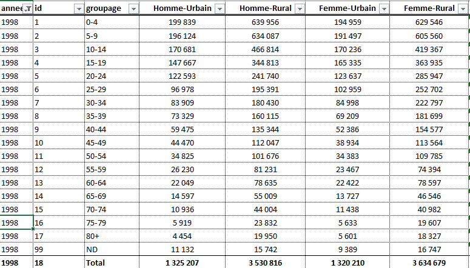

Dataframe dans MS Excel: zoom

## Sous Microsotf Excel (3)

On peut même faire des graphiques. C'est bien non ?

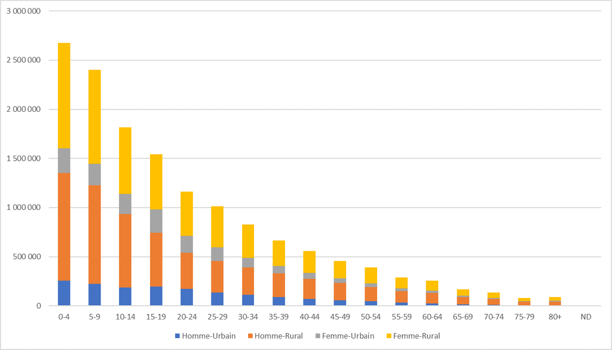

Graph dans MS Excel: barres empilées (population, 2009)

## Sous Microsotf Excel (4)

Absolument!

Et si l'on voulais faire une pyramide des âges ?

Alors là….

## Sous Microsotf Excel (5)

…il faudrait reorganiser les données…

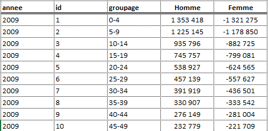

Dataframe dans MS Excel: un autre

## Sous Microsotf Excel (6)

…et éditer un nouveau graphique.

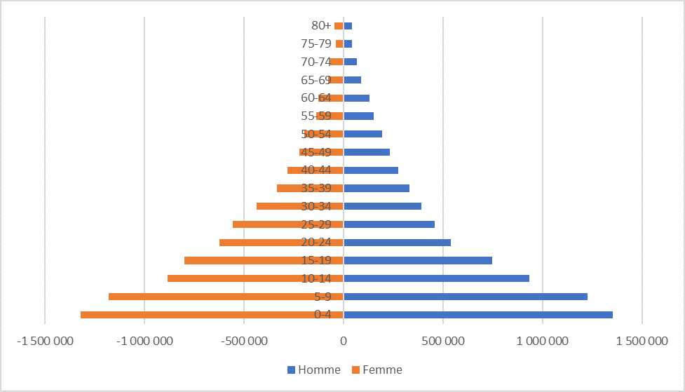

Graph dans MS Excel: barres (pyramide des âges, 2009)

## Sous Microsotf Excel (7)

Et si l'on voulait comparer les tranches d'âge sur deux années?

Disons, 1998 et 2009, les deux derniers recensements en date!

Là aussi, il faudrait…

## Sous Microsotf Excel (8)

…reorganiser les données et…

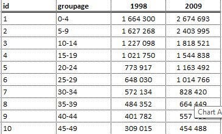

Dataframe dans MS Excel: encore un autre

## Sous Microsotf Excel (9)

…éditer un nouveau graphique…

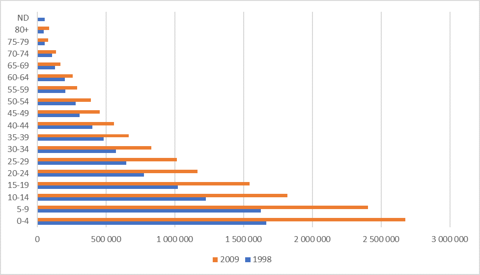

Graph dans MS Excel: barres (population: 1998 vs 2009)

## Sous Microsotf Excel (10)

Imaginez:

- si vous devez faire des pyramides pour toutes les régions, tous les cercles, toutes les communes? Où trouveriez-vous le temps de faire tous ces "clics" ? (pourriez-vous survivre à une telle épreuve?)
- si vous devez collaborer en temps réel avec d'autres personnes ces pyramides? Comment partageriez-vous le fichier ?
- si vous veniez à perdre votre fichier, ou avoir un virus ou à avoir votre version corrompue? Que feriez-vous?

Voici autant de raisons qui justifient l'adoption de langages/logiciels comme R pour le traitement de données.

## Sous R (1)

Que voit-on une fois dans le monde R?

Un aperçu des données rectangulaires

| annee | id | groupage | Homme-Urbain | Homme-Rural | Femme-Urbain | Femme-Rural | source | office |
| --- | --- | --- | --- | --- | --- | --- | --- | --- |
| 2009 | 1 | 0-4 | 257291 | 1096127 | 251243 | 1070032 | RGPH | DNSI |
| 2009 | 2 | 5-9 | 223556 | 1001589 | 221268 | 957582 | RGPH | DNSI |
| 2009 | 3 | 10-14 | 185770 | 750026 | 201984 | 680741 | RGPH | DNSI |
| 2009 | 4 | 15-19 | 196878 | 548879 | 236550 | 562531 | RGPH | DNSI |
| 2009 | 5 | 20-24 | 174109 | 364818 | 171861 | 452704 | RGPH | DNSI |

## Sous R (2)

L'histoire n'est pas finie. Nous n'avons toujours pas la clé à l'univers magique *tidyverse*. Les données ne sont pas organisées sur les principes *tidy* qui sont les suivants:

- chaque ligne est une observation ;
- chaque colonne est un attribut.

Jettons un autre coup d'oeil aux données.

## Sous R (3)

Un aperçu des données rectangulaires, encore

| annee | id | groupage | Homme-Urbain | Homme-Rural | Femme-Urbain | Femme-Rural | source | office |
| --- | --- | --- | --- | --- | --- | --- | --- | --- |
| 2009 | 1 | 0-4 | 257291 | 1096127 | 251243 | 1070032 | RGPH | DNSI |
| 2009 | 2 | 5-9 | 223556 | 1001589 | 221268 | 957582 | RGPH | DNSI |
| 2009 | 3 | 10-14 | 185770 | 750026 | 201984 | 680741 | RGPH | DNSI |
| 2009 | 4 | 15-19 | 196878 | 548879 | 236550 | 562531 | RGPH | DNSI |
| 2009 | 5 | 20-24 | 174109 | 364818 | 171861 | 452704 | RGPH | DNSI |
| 2009 | 6 | 25-29 | 133978 | 323161 | 137607 | 420020 | RGPH | DNSI |

## Sous R (4)

Qu'est-ce qui ne va pas?

- `Homme` et `Femme` apparaissent en colonnes, or ce sont deux catégories du même attribut: le sexe;
- `Urbain` et `Rural` apparaissent en colonnes, or ce sont deux catégories du même attribut: le milieu.

On doit passer du format large (*wide*) au format long (*long* ou ici *tidy*).

## Sous R (5)

En reorganisant les données, on obtient:

Des données tidy

| annee | id | groupage | sexe | milieu | population | source | office |
| --- | --- | --- | --- | --- | --- | --- | --- |
| 2009 | 1 | 0-4 | Homme | Urbain | 257291 | RGPH | DNSI |
| 2009 | 2 | 5-9 | Homme | Urbain | 223556 | RGPH | DNSI |
| 2009 | 3 | 10-14 | Homme | Urbain | 185770 | RGPH | DNSI |
| 2009 | 4 | 15-19 | Homme | Urbain | 196878 | RGPH | DNSI |
| 2009 | 5 | 20-24 | Homme | Urbain | 174109 | RGPH | DNSI |
| 2009 | 6 | 25-29 | Homme | Urbain | 133978 | RGPH | DNSI |

## Sous R (6)

Revoyons les données, mais sous un autre angle:

```r
# Un coup d'oeil
censuses_tidy
```

```
## # A tibble: 1,064 x 8
##    annee    id groupage sexe  milieu population source              office
##    <dbl> <dbl> <chr>    <chr> <chr>       <dbl> <chr>               <chr>
##  1  1968     1 0-4      Homme Urbain         NA Annuaire statistiq~ DNSI
##  2  1968     2 5-9      Homme Urbain         NA Annuaire statistiq~ DNSI
##  3  1968     3 10-14    Homme Urbain         NA Annuaire statistiq~ DNSI
##  4  1968     4 15-19    Homme Urbain         NA Annuaire statistiq~ DNSI
##  5  1968     5 20-24    Homme Urbain         NA Annuaire statistiq~ DNSI
##  6  1968     6 25-29    Homme Urbain         NA Annuaire statistiq~ DNSI
##  7  1968     7 30-34    Homme Urbain         NA Annuaire statistiq~ DNSI
##  8  1968     8 35-39    Homme Urbain         NA Annuaire statistiq~ DNSI
##  9  1968     9 40-44    Homme Urbain         NA Annuaire statistiq~ DNSI
## 10  1968    10 45-49    Homme Urbain         NA Annuaire statistiq~ DNSI
## # ... with 1,054 more rows
```

## Sous R (7)

Que gagnons-nous à les avoir sous cette forme? La réponse: tout! D'ici, il est possible de faire les mêmes graphiques que dans Excel, et plus encore. Par dessus tout, ici on est libéré des limites d'Excel. Juste trois arguments (en rapport avec les questions soulevées):

- l'évolutivité (*scalability*) : des fonctions exécutant des tâches en boucles (plutôt que les 'clics');
- la reproductibilité du travail à travers des scripts qui facilitent la collaboration et garantissent la transparence;
- le contrôle des versions avec la technologie Git (si ces meetups continuent, on en parlera, inévitablement): on peut aller en avant et revenir en arrière à souhait.

## Sous R (8)

Maintenant, passons dans le *tidyverse* avec *tidy data*.

## *Tidyverse* en action (enfin, juste un petite demonstration)

## L'écosystème du *tidyverse*

- Nous y sommes déjà, depuis le début de la présentation, ce sont des outils du *tidyverse* qui sont à l'oeuvre
- Un ensemble d'outils (packages) élaborés séparemment, mais de sorte à fonctionner ensemble et bâtis avec le même esprit
- Regardons comment est-ce que nos données rectangulaires *tidy* se prêtent à une variété de tâches

## Reprenons les graphiques (1)

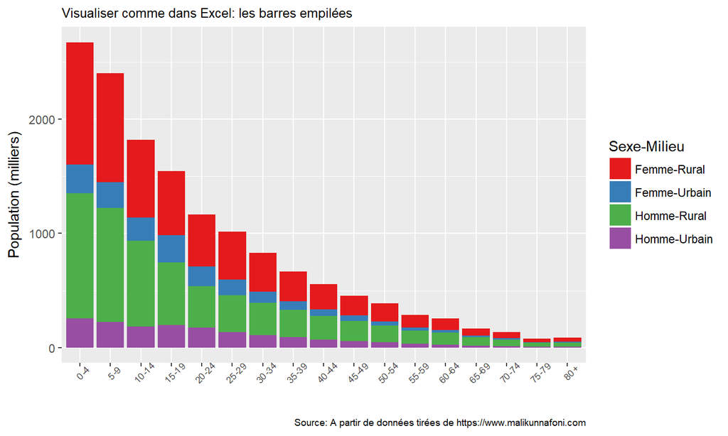

Population du Mali, 2009

## Reprenons les graphiques (1) (codes)

Regardez seulement le point de départ: `censuses_tidy`

```r
# Population en 2009
censuses_tidy %>%
  filter(annee == 2009,
         id < 18) %>%
  unite("sexemilieu", c(sexe, milieu), sep = "-") %>%
  ggplot(aes(x = reorder(groupage, id), y = population/1e3, fill = sexemilieu)) +
  geom_col(position = "stack") +
  theme(axis.text.x = element_text(angle = 45, size = 7),
        plot.caption = element_text(size = 7) ) +
  scale_fill_brewer(type = "seq", palette = "Set1") +
  labs(x = "", y = "Population (milliers)", fill = "Sexe-Milieu",
       caption = "Source: A partir de données tirées de https://www.malikunnafoni.com",
       subtitle = "Visualiser comme dans Excel: les barres empilées")
```

C'est le dataframe (données en format rectangulaire) que nous avons créeé à partir du fichier Excel: `censuses_tidy`. Vous le retrouverez partout!

## Reprenons les graphiques (2)

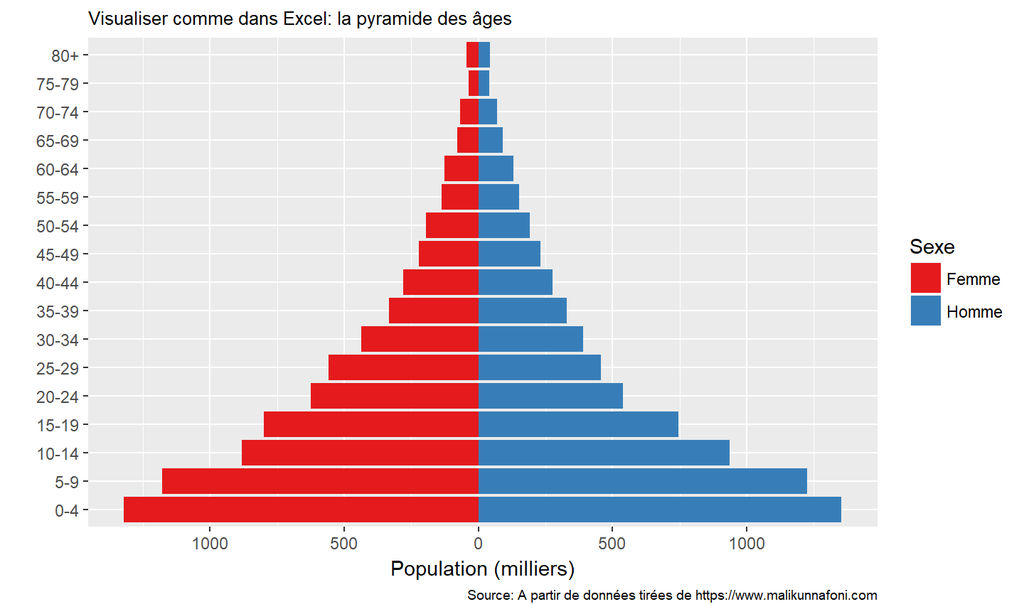

Population du Mali: la pyramide des âges, 2009

## Reprenons les graphiques (2) (codes)

```r
# Population en 2009
censuses_tidy %>%
  filter(annee == 2009,
         id < 18) %>%
  group_by(id, groupage, sexe) %>%
  summarise(population = sum(population)) %>%
  mutate(population = ifelse(sexe == "Femme", -population, population)) %>%
  ggplot(aes(x = reorder(groupage, id), y = population/1e3, fill = sexe)) +
  geom_col(position = "stack") +
  coord_flip() +
  theme(plot.caption = element_text(size = 7) ) +
  scale_fill_brewer(type = "seq", palette = "Set1") +
  scale_y_continuous(labels = abs) +
  labs(x = "", y = "Population (milliers)", fill = "Sexe",
       caption = "Source: A partir de données tirées de https://www.malikunnafoni.com",
       subtitle = "Visualiser comme dans Excel: la pyramide des âges")
```

Il encore est là!

## Reprenons les graphiques (3)

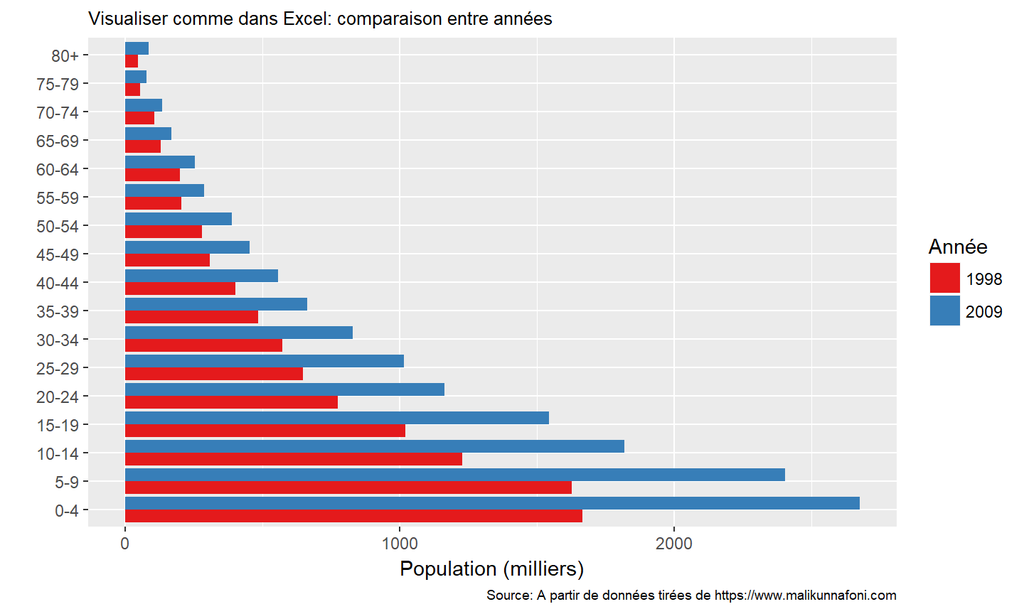

Population du Mali, 1998 vs 2009

## Reprenons les graphiques (3) (codes)

```r
# Population: 1998 vs 2009
censuses_tidy %>%
  filter(annee %in% c(1998, 2009),
         id < 18) %>%
  group_by(annee, id, groupage) %>%
  summarise(population = sum(population)) %>%
  ggplot(aes(x = reorder(groupage, id), y = population/1e3, fill = factor(annee))) +
  geom_col(position = "dodge") +
  coord_flip() +
  theme(plot.caption = element_text(size = 7) ) +
  scale_fill_brewer(type = "seq", palette = "Set1") +
  scale_y_continuous(labels = abs) +
  labs(x = "", y = "Population (milliers)", fill = "Année",
       caption = "Source: A partir de données tirées de https://www.malikunnafoni.com",
       subtitle = "Visualiser comme dans Excel: comparaison entre années")
```

Il encore est là!

## Arrêtons-nous un instant

Là réside la force du *tidyverse* et des *tidy data*. Une fois que les données sont dans la bonne forme - ici *tidy* -, elles deviennent malléables. Les outils du *tidyverse* permettent le séquençage des tâches (avec les *pipes* - vous saurez bientôt ce que c'est!). On peut ainsi partir des données *tidy* vers la visualisation, la modélisation ou souvent les deux, et plus encore. Avec les outils du *tidyverse*, les données organisées en format *tidy* se positionnent en point de départ du *workflow* du *data scientist*!

Maintenant, amusons-nous à soulever quelques questions et à tenter d'y apporter des réponses tout en gardant cette démarche: notre *tidy data* comme point de départ du *workflow*.

## Allons plus loin: les graphiques (1)

La pyramide des âges diffère-t-elle beaucoup entre milieu urbain et milieu rural?

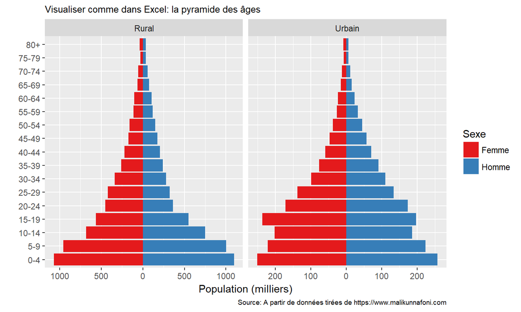

Population du Mali: la pyramide des âges urbain vs rural, 2009

## Allons plus loin: les graphiques (1) (c)

```r
# Population en 2009: urbain versus rural
censuses_tidy %>%
  filter(annee == 2009,
         id < 18) %>%
  mutate(population = ifelse(sexe == "Femme", -population, population)) %>%
  ggplot(aes(x = reorder(groupage, id), y = population/1e3, fill = sexe)) +
  geom_col(position = "stack") +
  coord_flip() +
  facet_wrap(~milieu, scales = "free_x") +
  theme(plot.caption = element_text(size = 7) ) +
  scale_fill_brewer(type = "seq", palette = "Set1") +
  scale_y_continuous(labels = abs) +
  labs(x = "", y = "Population (milliers)", fill = "Sexe",
       caption = "Source: A partir de données tirées de https://www.malikunnafoni.com",
       subtitle = "Visualiser comme dans Excel: la pyramide des âges")
```

`censuses_tidy` est toujours là!

## Allons plus loin: les graphiques (2)

Comment est-ce la population a évolué entre 1976 et 2009 au Mali? Quelle a été le volume de chaque groupe d'âge?

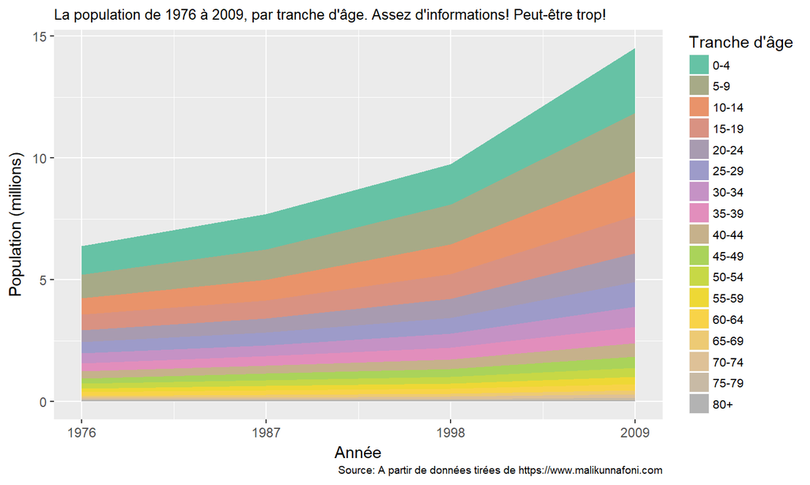

Population du Mali: par tranche d'âge, 1976-2009

## Allons plus loin: les graphiques (2) (c)

```r
# Quelques manipulations élargir la palette de couleurs
getPalette <- colorRampPalette(brewer.pal(9, "Set2"))

# Population: 1976-2009, par groupe d'âge
censuses_tidy %>%
  filter(source == "RGPH", id < 18) %>%
  group_by(annee, id, groupage) %>%
  summarise(population = sum(population)) %>%
  ggplot(aes(x = annee, y = population/1e6, fill = reorder(groupage, id))) +
  geom_area(position = "stack") +
  theme(plot.caption = element_text(size = 7),
        legend.text = element_text(size = 8),
        legend.key.size = unit(0.5, "cm")) +
  scale_fill_manual(values = getPalette(17)) +
  scale_x_continuous(breaks = c(1976, 1987, 1998, 2009)) +
  labs(x = "Année", y = "Population (millions)", fill = "Tranche d'âge",
       caption = "Source: A partir de données tirées de https://www.malikunnafoni.com",
       subtitle = "La population de 1976 à 2009, par tranche d'âge. Assez d'informations! Peut-être trop! ")
```

`censuses_tidy` : il n'est pas prêt de bouger celui-là!

## Allons plus loin: les graphiques (3)

Cherchons une réponse plus simple à la même question….mais pas trop simple.

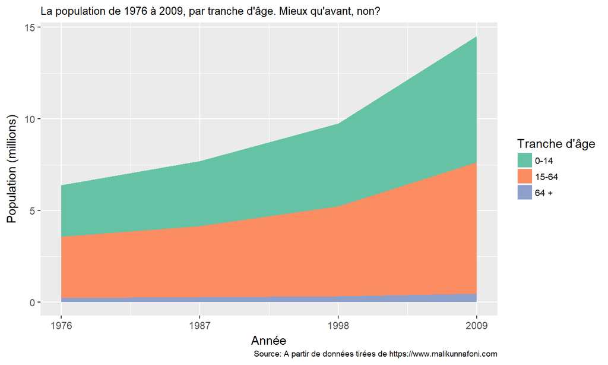

Population du Mali: par tranche d'âge, 1976-2009

## Allons plus loin: les graphiques (3) (c)

```r
# Population: 1976-2009, par groupe d'âge
censuses_tidy %>%
  filter(source == "RGPH", id < 18) %>%
  mutate(groupage2 = case_when(id > 0 & id <= 3 ~ "0-14",
                               id > 3 & id <= 13 ~ "15-64",
                               id > 13 & id <= 17 ~ "64 +")) %>%
  group_by(annee, groupage2) %>%
  summarise(population = sum(population)) %>%
  ggplot(aes(x = annee, y = population/1e6, fill = groupage2)) +
  geom_area(position = "stack") +
  theme(plot.caption = element_text(size = 7),
        legend.text = element_text(size = 8),
        legend.key.size = unit(0.5, "cm")) +
  scale_fill_brewer(type = "seq", palette = "Set2") +
  scale_x_continuous(breaks = c(1976, 1987, 1998, 2009)) +
  labs(x = "Année", y = "Population (millions)", fill = "Tranche d'âge",
       caption = "Source: A partir de données tirées de https://www.malikunnafoni.com",
       subtitle = "La population de 1976 à 2009, par tranche d'âge. Mieux qu'avant, non? ")
```

- "`censuses_tidy`"?
- "Présent!"

## Allons plus loin: les graphiques (4)

Quelle lecture peut-on faire des taux de croissance de la population, tranche d'âge, par sexe et par milieu ?

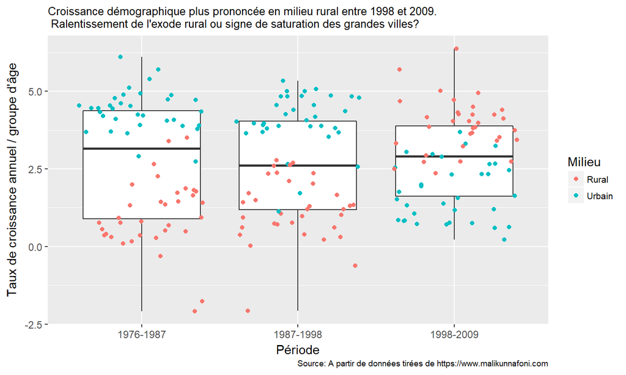

Population du Mali: taux de croissance, 1976-2009

## Allons plus loin: les graphiques (4) (c)

```r
# Population: Le taux de croissance, par tranche d'âge, urbain vs rural
censuses_tidy %>%
  filter(source == "RGPH", id < 18) %>%
  group_by(groupage, sexe, milieu) %>%
  mutate(rate = population / lag(population),
         duration = annee - lag(annee),
         perannum = rate^(1/duration),
         taux = (-1 + perannum)*100,
         periode = paste(lag(annee), annee, sep = "-")) %>%
  filter(!is.na(taux)) %>%
  ggplot(aes(x = periode, y = taux)) +
  geom_boxplot() +
  geom_point(aes(color = milieu), position = "jitter") +
  theme(plot.caption = element_text(size = 7),
        legend.text = element_text(size = 8),
        legend.key.size = unit(0.5, "cm")) +
  labs(x = "Période", y = "Taux de croissance annuel / groupe d'âge", color = "Milieu",
       caption = "Source: A partir de données tirées de https://www.malikunnafoni.com",
       subtitle = "Croissance démographique plus prononcée en milieu rural entre 1998 et 2009. \n Ralentissement de l'exode rural ou signe de saturation des grandes villes? ")
```

## Allons plus loin: les graphiques (5)

Et si l'on voulait projeter la population du Mali sur dix ans dans le futur?

[figure not shown]

Population du Mali: les 0-4 ans, 1968-2020

## Allons plus loin: les graphiques (5) - 1 (c)

```r
# Définition d'un modèle pour la projection de la population sur 2010-2020
modele_projections <- function(df) {
  df <- df %>%
    bind_rows(
      data_frame(
        annee = seq(2010, 2020, by = 1),
        population = rep(NA, length(c(2010:2020))),
        source = rep("Projections", length(c(2010:2020))),
        office = rep("Auteur", length(c(2010:2020)))
        )
    )
  pop_lm <- lm(log(population) ~ annee, data = df) # Modèle linéaire de projection
  df <- df %>% add_predictions(pop_lm) # Ajout des prédictions à la data frame
}
```

## Allons plus loin: les graphiques (5) - 2 (c)

```r
# Population: Application du modèle aux données + représentation graphique de 0-4 ans
censuses_tidy %>%
  filter(id < 18) %>% # On garde même les points intermédiaires
  group_by(id, groupage, sexe, milieu) %>%
  nest() %>%
  mutate(long_data = map(data, modele_projections)) %>%
  select(- data) %>%
  unnest() %>%
  mutate(pred = exp(pred),
         type = case_when(annee <= 2009 ~ "Passé",
                          annee  > 2009 ~ "Futur"),
         type = factor(type, levels = c("Passé", "Futur"), labels = c("Passé", "Futur"), ordered = TRUE ),
         source2 = case_when(source == "RGPH" ~ "RGPH",
                             !(source == "RGPH") ~ "Autre")) %>%
  filter(id == 1) %>%
  ggplot() +
  geom_point(aes(x = annee, y = population/1e6, color = source2)) +
  geom_line(aes(x = annee, y = pred/1e6, linetype = type)) +
  facet_grid(milieu ~ sexe, scales = "free") +
  theme(plot.caption = element_text(size = 7),
        legend.text = element_text(size = 8),
        legend.key.size = unit(0.5, "cm")) +
  labs(x = "Année", y = "Population (millions)", color = "Source", linetype = "Temps",
       caption = "Source: A partir de données tirées de https://www.malikunnafoni.com",
       subtitle = "A l'horizon 2020, 1 personne sur 3 de 0-4 ans sera en milieu urbain contre 1 sur 4 en 1968")
```

## Arrêtons-nous un instant, encore

Nous venons de voir quelques prouesses du *tidyverse*. Avec des données rectangulaires ordonnées dans la bonne disposition, *tidy*, nous parvenons à séquencer plusieurs actions qui peuvent aboutir sur des tableaux ou des graphiques. Mieux encore, nous parvenons à faire appels à plusieurs fonctions issues de différents *packages*.

Maintenant, faisons connaissance avec les packages du *tidyverse*.

## *Tidyverse*: tout un écosystème

## Comment *tidyverse* se présente lui-même?

*The tidyverse is an opinionated collection of R packages designed for data science.* *All packages share an underlying design philosophy, grammar, and data structures.* site web du *tidyverse*: https://www.tidyverse.org/

Tidyverse comprend un certain nombre de packages qui forment son coeur et qui sont automatiquement chargés dans R quand on fait appel à la collection. Il en contient d'autres qui sont périphériques, et qui nécessitent des appels séparés.

## Les packages: le coeur

[figure not shown]

[figure not shown]

[figure not shown]

[figure not shown]

[figure not shown]

[figure not shown]

[figure not shown]

[figure not shown]

## Les packages: la périphérie (non exhaustive)

- *readxl* et haven pour importer des données
- *lubridate* pour manipuler les dates
- *glue* pour la combinaison de données et de caractères
- *modelr* pour introduire des résultats ou objets liés à la modélisation dans un *workflow*

Un univers en expansion.